# Equivalence of BYM2 Implementations: ICAR+Constraint vs Reduced-Rank Basis

```r
library(Matrix)
# (Optional) library(RSpectra) # for scalable eigen if you later increase N
```

## 1. The objects and the claim

Let $W$ be the symmetric $0/1$ adjacency and $L = D - W$ the graph Laplacian on a **connected** graph; $D = \mathrm{diag}(W\mathbf 1)$.
The ICAR prior on the constrained subspace $\{\mathbf 1^\top \phi = 0\}$ has density
$$\pi(\phi)\ \propto\ \exp\Big(-\tfrac12\,\phi^\top Q\,\phi\Big),\qquad Q
:= L.$$
Its (singular) covariance is the Moore–Penrose inverse $Q^+$ on $\mathbf 1^\perp$.
Let the eigen-decomposition be $L = U \Lambda U^\top$ with $\Lambda = \mathrm{diag}(0,\lambda_2,\ldots,\lambda_N)$ and $U = [u_1=\tfrac{\mathbf 1}{\sqrt N},\ U_+]$. Then
$$Q^+ \;=\; U_+
\,\mathrm{diag}\!\big(\lambda_2^{-1},\ldots,\lambda_N^{-1}\big)\,
U_+^\top.$$

The BYM2 **geometric-mean** scale is
$$s \ :=\ \operatorname{GM}\!\big(\operatorname{diag}(Q^+)\big)
\ =\ \exp\!\left(\frac{1}{N}\sum_{i=1}^N \log (Q^+)_{ii}\right).$$

Define the reduced-rank basis (size $N\times(N-1)$)
$$R \ :=\ \frac{1}{\sqrt{s}}\
U_+\,\mathrm{diag}\!\big(\lambda_2^{-1/2},\ldots,\lambda_N^{-1/2}\big).$$

**Key properties**: 1. $\mathbf 1^\top R = 0$ (each column lies in $\mathbf 1^\perp$). 2. $R R^\top = Q^+ / s$. 3. $\operatorname{GM}\{\operatorname{diag}(R R^\top)\} = 1$.

Hence if $\eta \sim \mathcal N(0,I_{N-1})$, then $\phi := R\eta$ has covariance $Q^+/s$ and geometric-mean marginal variance $=1$. This is exactly the structured BYM2 piece used in both parameterizations: - **ICAR + constraint (Stan Model 1)**: sample $\phi$ on $\mathbf 1^\perp$ with precision $Q$ and scale by $1/\sqrt{s}$ (via `scale_factor`). - **Reduced-rank basis (Stan Model 2)**: set $\phi = R\eta$ with $\eta\sim \mathcal N(0,I)$.

## 2. Build a connected grid and its Laplacian

```r
# 4-neighbor grid adjacency (connected if nx>1 and ny>1)
make_grid_adj <- function(nx, ny) {
  stopifnot(nx >= 1L, ny >= 1L)
  if (nx*ny == 1L) return(Matrix(0,1,1, sparse = TRUE))
  Tx <- bandSparse(nx, k=c(-1,1), diag = list(rep(1, nx-1), rep(1, nx-1)))
  Ty <- bandSparse(ny, k=c(-1,1), diag = list(rep(1, ny-1), rep(1, ny-1)))
  W  <- kronecker(Diagonal(ny), Tx) + kronecker(Ty, Diagonal(nx))
  W@x[] <- 1
  forceSymmetric(drop0(W), uplo = "U")
}

nx <- 20; ny <- 20
W  <- make_grid_adj(nx, ny)
N  <- nrow(W)
d  <- Matrix::rowSums(W)
L  <- Diagonal(x = as.numeric(d)) - W  # Laplacian
```

## 3. Compute $Q^+$, BYM2 scale $s$, and the reduced-rank basis $R$

```r
# Dense eigendecomp is fine for N=400; for larger N consider RSpectra::eigs_sym
Ee  <- eigen(as.matrix(L), symmetric = TRUE)
lam <- Ee$values
U   <- Ee$vectors

# Sort ascending (defensive)
o        <- order(lam)
lam      <- lam[o]
U        <- U[, o, drop = FALSE]
lam_pos  <- lam[-1]                    # drop the single zero eigen
U_pos    <- U[, -1, drop = FALSE]

# diag(Q^+) = rowSums(U_pos^2 %*% (1/lam_pos))
diag_Qp  <- as.numeric((U_pos^2) %*% (1/lam_pos))
s_bym2   <- exp(mean(log(diag_Qp)))    # geometric-mean scale

# Reduced-rank BYM2 basis: R = (1/sqrt(s)) * U_pos * diag(lam_pos^(-1/2))
R <- sweep(U_pos, 2L, lam_pos^(-1/2), `*`) / sqrt(s_bym2)

# Sanity checks
RRt <- R %*% t(R)

c(
  one_is_orthogonal = max(abs(drop(crossprod(rep(1, N), R)))),
  gmvar_RRt         = exp(mean(log(diag(RRt)))),
  max_abs_diff_diag = max(abs(diag(RRt) - diag_Qp / s_bym2))
)
```

```
## one_is_orthogonal         gmvar_RRt max_abs_diff_diag
##      2.129200e-12      1.000000e+00      6.217249e-15
```

You should see `one_is_orthogonal` ≈ 0, `gmvar_RRt` ≈ 1, and `max_abs_diff_diag` near machine precision.

Optionally, a stronger matrix-level check:

```r
# Frobenius relative error between RR^T and Q^+/s
Qp_over_s <- U_pos %*% (t(U_pos) / lam_pos)
Qp_over_s <- Qp_over_s / s_bym2

num <- norm(RRt - Qp_over_s, type = "F")
den <- norm(Qp_over_s,       type = "F")
num / den
```

```
## [1] 1.326955e-15
```

## 4. Deterministic equality of the two phi constructions

Define two **deterministic** constructions of the structured field: - **ICAR–spectral**: $\phi_A = \frac{1}{\sqrt{s}}\,U_+\,\mathrm{diag}(\lambda_+^{-1/2})\,z$ - **Reduced-rank basis**: $\phi_B = R\,z$

Using the **same fixed** $z$, these are **algebraically identical**.

```r
set.seed(42)
z <- seq_len(ncol(R)) / ncol(R)   # deterministic vector (any fixed z works)

phi_A <- (U_pos %*% (z / sqrt(lam_pos))) / sqrt(s_bym2)  # ICAR–spectral
phi_B <- R %*% z                                         # Reduced-rank basis

c(
  max_abs_diff      = max(abs(phi_A - phi_B)),
  mean_abs_diff     = mean(abs(phi_A - phi_B)),
  sum_to_zero_A     = sum(phi_A),
  sum_to_zero_B     = sum(phi_B)
)
```

```
##  max_abs_diff mean_abs_diff sum_to_zero_A sum_to_zero_B
##  1.221245e-15  1.488582e-16 -3.164136e-15 -1.304512e-15
```

Visual comparison:

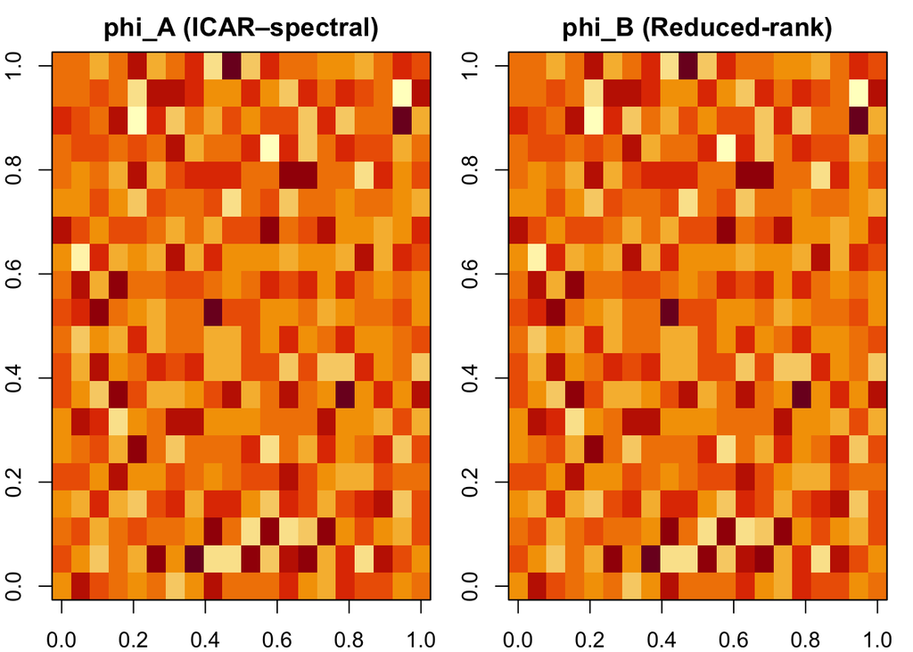

```r
par(mfrow=c(1,2), mar=c(2,2,2,1))
image(matrix(phi_A, nx, ny), main="phi_A (ICAR–spectral)"); box()
image(matrix(phi_B, nx, ny), main="phi_B (Reduced-rank)"); box()
```